# Lab 4 Web Scraping and API 101

## Lab 4 Part 2. Basic Intro to R and Preprossing Textual Data with R

We were able to successfully scrape the BLM protest events dataset. You can access the dataset https://yongjunzhang.com/files/blm-data.tsv

#### We need to load some packages for use

```r
if (!requireNamespace("pacman")) install.packages('pacman')
library(pacman)
packages<-c("tidyverse","tidytext","rvest", "RSelenium","coreNLP",
            "tm","haven","readxl","here","knitr","stopwords")
p_load(packages,character.only = TRUE)
```

#### Load blm-data tsv file

R tidyverse package provides a series of useful data wrangling tools. You can check it here https://www.tidyverse.org/. The tidyverse package installs a number of other packages for reading data:

1. **DBI** for relational databases. You’ll need to pair DBI with a database specific backends like RSQLite, RMariaDB, RPostgres, or odbc. Learn more at https://db.rstudio.com.
2. **haven** for SPSS, Stata, and SAS data.
3. **httr** for web APIs.
4. **readxl** for .xls and .xlsx sheets.
5. **rvest** for web scraping.
6. **jsonlite** for JSON. (Maintained by Jeroen Ooms.)
7. **xml2** for XML.

```r
# read tsv file using read_csv
data <- read_tsv(url("https://yongjunzhang.com/files/blm-data.tsv"))
# Show a table for visual check
knitr::kable(data[1:3,],cap="Black Lives Matter Protest (elephrame.com)")
```

Black Lives Matter Protest (elephrame.com)

| page_id | protest_id | protest_location | protest_start | protest_end | protest_subject | protest_participants | protest_time | protest_description | protest_urls |
| --- | --- | --- | --- | --- | --- | --- | --- | --- | --- |
| 1 | 6730 | London, England - happened? | Tuesday, October 19, 2021 | - Present | Subject(s): Local - Monument - Robert Geffyre, History - Slavery | Participant(s): Unclear | Time: Continuous | Description: Boycott of Museum of the Home over statue of Geffrye, who made money from slave trade | Source(s):##https://www.hackneycitizen.co.uk/2021/10/19/campaigners-museum-boycott-calls-teachers-families-join-slaver-statue/ |
| 1 | 4538 | Minneapolis, MN | Friday, June 5, 2020 | - Present | Subject(s): General - Police Brutality | Participant(s): 15 | Time: Continuous | Description: “Say Their Names” symbolic cemetery of 100 Black people killed by police | Source(s):##https://www.minneapolis.org/support-black-lives/38th-and-chicago/##https://theconversation.com/black-deaths-matter-the-centuries-old-struggle-to-memorialize-slaves-and-victims-of-racism-14… |
| 1 | 2948 | Minneapolis, MN | Tuesday, May 26, 2020 | - Present | Subject(s): George Floyd | Participant(s): Hundreds-Thousands (est.) | Time: Continuous | Description: Makeshift memorial at site where Floyd was killed | Source(s):##https://twitter.com/bengarvin/status/1267291981266530305##https://twitter.com/stribrooks/status/1266005779158568963##https://twitter.com/OmarJimenez/status/1265394526379806720 |

#### Clean blm-data

Let us say, we need to create variables like state and city; we also want to clean some variables like subjects, description, etc.

```r
data <- data %>%
  # split location
  separate(protest_location,c("city","state"),sep = ",",remove = T) %>%
  # split protest start time
  separate(protest_start,c("day","date","year"),sep = ",",remove = T) %>%
  # clean subjects and participants
  mutate(
    protest_subject = str_replace(protest_subject,"Subject\\(s\\): ",""),
    protest_participants = str_replace(protest_participants,"Participant\\(s\\): ",""),
    protest_time = str_replace(protest_time,"Time: ",""),
    protest_description = str_replace(protest_description,"Description: ",""),
    protest_urls = str_replace(protest_urls,"Source\\(s\\):","")
    )
# Show a table for visual check
knitr::kable(data[1:3,],cap="Black Lives Matter Protest (elephrame.com)")
```

Black Lives Matter Protest (elephrame.com)

| page_id | protest_id | city | state | day | date | year | protest_end | protest_subject | protest_participants | protest_time | protest_description | protest_urls |
| --- | --- | --- | --- | --- | --- | --- | --- | --- | --- | --- | --- | --- |
| 1 | 6730 | London | England - happened? | Tuesday | October 19 | 2021 | - Present | Local - Monument - Robert Geffyre, History - Slavery | Unclear | Continuous | Boycott of Museum of the Home over statue of Geffrye, who made money from slave trade | ##https://www.hackneycitizen.co.uk/2021/10/19/campaigners-museum-boycott-calls-teachers-families-join-slaver-statue/ |
| 1 | 4538 | Minneapolis | MN | Friday | June 5 | 2020 | - Present | General - Police Brutality | 15 | Continuous | “Say Their Names” symbolic cemetery of 100 Black people killed by police | ##https://www.minneapolis.org/support-black-lives/38th-and-chicago/##https://theconversation.com/black-deaths-matter-the-centuries-old-struggle-to-memorialize-slaves-and-victims-of-racism-140613##http… |
| 1 | 2948 | Minneapolis | MN | Tuesday | May 26 | 2020 | - Present | George Floyd | Hundreds-Thousands (est.) | Continuous | Makeshift memorial at site where Floyd was killed | ##https://twitter.com/bengarvin/status/1267291981266530305##https://twitter.com/stribrooks/status/1266005779158568963##https://twitter.com/OmarJimenez/status/1265394526379806720 |

### Using Tidytest package to process some variables

There are a variety of processing text packages. Today we briefly introduce tidytext package. You can check herehttps://cran.r-project.org/web/packages/tidytext/vignettes/tidytext.html; This tidytext toturial heavily relies on Julia Silge and David Robinson’s work. You can also check their book Text Mining with R here https://www.tidytextmining.com/

```r
library(tidytext)

# Let us say we are interested in protest description. We need to restructure it as one-token-per-row format. The unnest_tokens function is a way to convert a dataframe with a text column to be one-token-per-row:

tidy_data <- data %>%
  # protest_urls is messay, let us get rid of it first
  select(-protest_urls) %>%
  # one token per row. This function uses the tokenizers package to separate each line into words. The default tokenizing is for words, but other options include characters, ngrams, sentences, lines, paragraphs, or separation around a regex pattern.
  unnest_tokens(word, protest_description) %>%
  # remove stop words
  anti_join(tidytext::get_stopwords("en",source="snowball")) %>%
  # you can also add your own stop words if you want
  # check here to see tibble data structure <https://tibble.tidyverse.org/>
  anti_join(tibble(word=c("no","details")),by="word")
knitr::kable(tidy_data[1:10,],cap="Black Lives Matter Protest (elephrame.com)")
```

Black Lives Matter Protest (elephrame.com)

| page_id | protest_id | city | state | day | date | year | protest_end | protest_subject | protest_participants | protest_time | word |
| --- | --- | --- | --- | --- | --- | --- | --- | --- | --- | --- | --- |
| 1 | 6730 | London | England - happened? | Tuesday | October 19 | 2021 | - Present | Local - Monument - Robert Geffyre, History - Slavery | Unclear | Continuous | boycott |
| 1 | 6730 | London | England - happened? | Tuesday | October 19 | 2021 | - Present | Local - Monument - Robert Geffyre, History - Slavery | Unclear | Continuous | museum |
| 1 | 6730 | London | England - happened? | Tuesday | October 19 | 2021 | - Present | Local - Monument - Robert Geffyre, History - Slavery | Unclear | Continuous | home |
| 1 | 6730 | London | England - happened? | Tuesday | October 19 | 2021 | - Present | Local - Monument - Robert Geffyre, History - Slavery | Unclear | Continuous | statue |
| 1 | 6730 | London | England - happened? | Tuesday | October 19 | 2021 | - Present | Local - Monument - Robert Geffyre, History - Slavery | Unclear | Continuous | geffrye |
| 1 | 6730 | London | England - happened? | Tuesday | October 19 | 2021 | - Present | Local - Monument - Robert Geffyre, History - Slavery | Unclear | Continuous | made |
| 1 | 6730 | London | England - happened? | Tuesday | October 19 | 2021 | - Present | Local - Monument - Robert Geffyre, History - Slavery | Unclear | Continuous | money |
| 1 | 6730 | London | England - happened? | Tuesday | October 19 | 2021 | - Present | Local - Monument - Robert Geffyre, History - Slavery | Unclear | Continuous | slave |
| 1 | 6730 | London | England - happened? | Tuesday | October 19 | 2021 | - Present | Local - Monument - Robert Geffyre, History - Slavery | Unclear | Continuous | trade |
| 1 | 4538 | Minneapolis | MN | Friday | June 5 | 2020 | - Present | General - Police Brutality | 15 | Continuous | say |

## Part 3. Basic Analysis of Textual Data

### Let us get a count vector for protest description, like what are the most frequent words or bi-grams

```r
tidy_data %>%
  count(word, sort = TRUE)
```

```
## # A tibble: 4,628 × 2
##    word              n
##    <chr>         <int>
##  1 demonstration  2005
##  2 included       1995
##  3 march          1284
##  4 rally          1002
##  5 outside         575
##  6 police          502
##  7 national        478
##  8 walkout         458
##  9 game            432
## 10 anthem          426
## # … with 4,618 more rows
```

We can further plot this! I don’t like wordcloud, so I just do a simple bar plot.

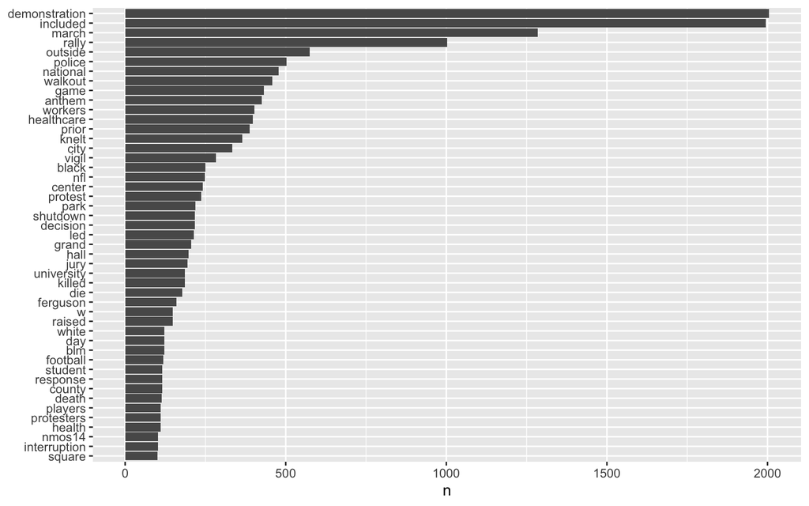

```r
library(ggplot2)

tidy_data %>%
  count(word, sort = TRUE) %>%
  filter(n > 100) %>%
  mutate(word = reorder(word, n)) %>%
  ggplot(aes(word, n)) +
  geom_col() +
  xlab(NULL) +
  coord_flip()
```

**let us get bigram**

```r
 data %>%
  select(-protest_urls) %>%
  unnest_tokens(bigram, protest_description,token = "ngrams", n = 2) %>%
  count(bigram,sort = TRUE)
```

```
## # A tibble: 14,844 × 2
##    bigram                 n
##    <chr>              <int>
##  1 for this            1968
##  2 no details          1968
##  3 this demonstration  1954
##  4 details included    1953
##  5 included for        1953
##  6 national anthem      408
##  7 healthcare workers   389
##  8 walkout of           388
##  9 prior to             387
## 10 during national      383
## # … with 14,834 more rows
```

You can check text mining with R book here https://www.tidytextmining.com/tfidf.html#tfidf

```r
tidy_words <- tidy_data %>%
  count(protest_id, word, sort = TRUE)

tidy_words
```

```
## # A tibble: 34,317 × 3
##    protest_id word        n
##         <dbl> <chr>   <int>
##  1       2414 march       4
##  2       1370 square      3
##  3       1480 high        3
##  4       2556 police      3
##  5       2767 city        3
##  6       4501 center      3
##  7       4753 workers     3
##  8       5762 nevada      3
##  9       6020 police      3
## 10         11 w           2
## # … with 34,307 more rows
```

## Part 4. Let us use R to replicate some webscraping

Let us say we want to go deeper about BLM data. The BLM-DATA.TSV provides the original protest urls (news articles). We want to process those original articles to get more info.

### Let us use httr or rvest to scrape a couple of news articles for example.

```r
# create a dataset having urls, year, and ids
urls <- data %>%
  select(protest_id,state,date,protest_urls) %>%
  # let us extract all protest_urls
  mutate(protest_urls=str_replace_all(protest_urls,"^##|^#","")) %>%
  separate_rows(protest_urls,sep="##") %>%
  filter(str_detect(protest_urls,"^http"))

# only keep one url for each protest
urls1 <- urls %>%
  distinct(protest_id,.keep_all = T)

# let us take a look at the data
knitr::kable(urls1[1:5,],cap="Black Lives Matter Protest (elephrame.com)")
```

Black Lives Matter Protest (elephrame.com)

| protest_id | state | date | protest_urls |
| --- | --- | --- | --- |
| 6730 | England - happened? | October 19 | https://www.hackneycitizen.co.uk/2021/10/19/campaigners-museum-boycott-calls-teachers-families-join-slaver-statue/ |
| 4538 | MN | June 5 | https://www.minneapolis.org/support-black-lives/38th-and-chicago/ |
| 2948 | MN | May 26 | https://twitter.com/bengarvin/status/1267291981266530305 |
| 6754 | MN | February 5 | https://www.startribune.com/protest-of-police-killing-of-amir-locke-draws-hundreds-to-minneapolis/600143527/ |
| 6755 | MN | February 4 | https://minnesota.cbslocal.com/2022/02/05/car-caravan-rolls-through-downtown-minneapolis-in-protest-of-amir-locke-killing/ |

Use httr and rvest packages to get access to articles. Note that a lot of news articles need special subscription to get access such as facebook, wp, etc.

rvest and httr have a lot of functions. here is an overview (credit to GITHUB:yusuzech)

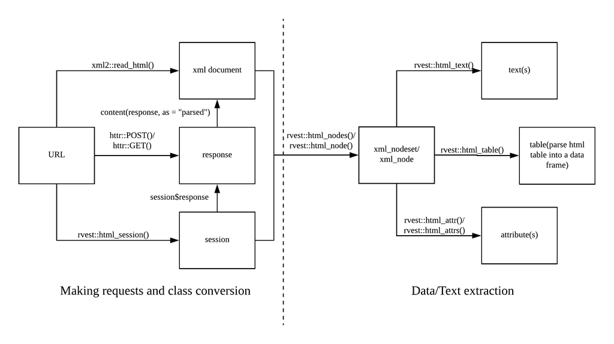

```r
knitr::include_graphics('rvest_httr.png')
```

```r
library(rvest)
library(httr)
url <- urls1$protest_urls[1]
url
```

```
## [1] "https://www.hackneycitizen.co.uk/2021/10/19/campaigners-museum-boycott-calls-teachers-families-join-slaver-statue/"
```

```r
# rvest provides two ways of making request: read_html() and html_session()
# read_html() can parse a HTML file or an url into xml document.
# html_session() is built on GET() from httr package.

#making GET request andparse website into xml document
pagesource <- read_html(url)

#using html_session which creates a session and accept httr methods
my_session <- session(url)

#html_session is built upon httr, you can access response with a session
response <- my_session$response

#retrieve content as raw
content_raw <- content(my_session$response,as = "raw")
#retrieve content as text
content_text <- content(my_session$response,as = "text")
#retrieve content as parsed(parsed automatically)
content_parsed <- content(my_session$response,as = "parsed")
```

> Obviously it returns a bunch of messy stuff; You need to use RSelenium to scrape these dynamic websites; we have learnt basic Selenium stuff in python. You can read this turorial for more details https://ropensci.org/tutorials/rselenium_tutorial/

### Here let me briefly show you we can also do this in R

```r
# connect to chrome driver
driver <- RSelenium::rsDriver(browser = "chrome",port = 4443L)
remote_driver <- driver[["client"]]
remote_driver$navigate(url)
```

```r
# retrieve the article

main_article <- remote_driver$findElement(using = "class", value="p402_premium")

text <- main_article$getElementText()
```

### Text is a messy list, you need to do some cleaning again.

```r
# let us clean those special characters like \n \t, etc.

tidy_text <- text[[1]] %>%
  # remove all whitespaces, note it is regex \t
  str_replace_all("\\s"," ") %>%
  # reove some weird punct
  str_replace_all('\\"',"") %>%
  # remove some double spaces
  str_squish %>%
  # reve spaces at the begining and end of the text
  str_trim %>%
  # lower case
  tolower()

tidy_text
```

**VOILA, we have a nice tidy text!!!**

# Code Challenge 2

> Use R selenium to scrape tripadvisor’s comments on “The Holocaust Memorial - Memorial to the Murdered Jews of Europe” https://www.tripadvisor.com/Attraction_Review-g187323-d617423-Reviews-The_Holocaust_Memorial_Memorial_to_the_Murdered_Jews_of_Europe-Berlin.html

> It has 17,850 commnets. All you need to do is to show me you can scrape first 10 pages.

> You codes should be written in Rmarkdown file and genearte a pdf file. ALso send me the final csv file.

> If you feel you have some difficulty, you are allowed to discuss with your collegues. But you should independently write your own codes. You can also consult with my codes here: https://yongjunzhang.com/intro2css/assets/files/tripadvisor.R. Pls do not just copy and paste my codes.